# readable_huntington_model

- 1. Introduction
- 2. Python dependencies
- 3. Downloading and initial processing of the Series Matrix file
  - 3.1 Downloading the Series Matrix file over FTP, unless the file is already present
  - 3.2 Decompressing the Series Matrix file
  - 3.3 Data pre-processing
    - 3.3.1 Storing the relevant metadata as python lists
    - 3.3.2 Printing relevant metadata for the first 5 and the last 5 samples respectively
    - 3.3.3 Setting up a list of indices of the discovery set data
    - 3.3.4 Picking up metadata for the samples belonging to the discovery set
    - 3.3.5 Loading the expression data
- 4. Computing Pearson's correlation coefficient of any gene and modal allele
- 5. Slicing and dicing a numpy array
  - 5.1 That's how we can choose given samples from our array
  - 5.2 That's how we can choose given genes from our array
- 6. Choosing top n genes and the training set from `probeset_data`
  - 6.1 Choosing the training set
    - 6.1.1 Testing for off-by-one errors
  - 6.2 Choosing top genes
  - 6.3 Split our data into training and testing indices
  - 6.4 Filtering modal_allele labels
  - 6.5 Testing that labels are correctly assigned (not permuted)
  - 6.6 Utility functions to change lists into row or column vectors
  - 6.7 Fitting the model
- 7. Viewing top correlating genes
- 8. Combining defined utility functions into a single `simulation_step` function
- 9. Running the simulation 200 times and produce the scatter plot, r and r-squared
- 10. Runing a simulation to compute the probability that a random predictor would achieve the same $r^2$ or better (estimating the p-value)
- 11. Printing the lowest $r^2$ which achieves a p-value of 0.05

# 1. Introduction

The purpose of this note is to show how one can reproduce some of the statistical analysis of [Lee et al.](https://doi.org/10.1093/hmg/ddt176), using data made accessible by the authors of the paper on [Gene Expression Ombibus (GEO), accession code GSE34721](https://www.ncbi.nlm.nih.gov/geo/query/acc.cgi?acc=GSE34721).

The reason we decided to replicate the analysis presented in the paper was two-fold:

1. We wanted to convince ourselves that the analysis is free of substantial errors.
2. We would like to apply their approach to a similar, previously unpublished dataset.

The added benefit of this replication is that we make our pipeline publically accessible, and freely usable to other researchers in the field.

Among other claims, [Lee et al.](https://doi.org/10.1093/hmg/ddt176) propose the following:

For details specific to each of this claims, in particular the exact type of cell line and microarray chip, please see the [original study](https://doi.org/10.1093/hmg/ddt176).

We believe that all of these claims are well supported by the mRNA expression and repeat length retrieved from one of the data files we accessed on GEO.

In this note we do not attempt to carefully verify other aspects of the study, among others:

1. How the patients were sampled & assigned to various batches.
2. How the raw data were normalised & the Series Matrix file constructed.

# 2. Python dependencies

All of the python dependencies used in this replication study are standard python packages. You can download them either manually or using pip. Please ensure that your python version is 3.6, and `pip` is installing packages for the correct python distribution. Depending on your system and your particular setup, your `pip` executable may be actually named `pip3`, and its location may vary.

The safest option is to install an isolated python 3.6 environment using virtualenv, which on most systems can be accomplished using the following, or similar shell commands:

`pip install -r requirements.txt`

```python
from ftplib import FTP
import os
import gzip
import numpy as np
from scipy.stats import pearsonr
from sklearn.cross_decomposition import PLSRegression
from matplotlib import pyplot as plt
%matplotlib inline
```

# 3. Downloading and initial processing of the Series Matrix file

## 3.1 Downloading the Series Matrix file over FTP, unless the file is already present

```python
series_matrix_name = "Lee_2013_series_matrix.gz"
```

```python
if series_matrix_name not in os.listdir():
    ftp = FTP('ftp.ncbi.nlm.nih.gov')
    print(ftp.login())
    print(ftp.cwd("geo/series/GSE34nnn/GSE34721/matrix/"))
    print(ftp.retrbinary('RETR GSE34721_series_matrix.txt.gz', open(series_matrix_name, 'wb').write))
```

## 3.2 Decompressing the Series Matrix file

```python
with gzip.open(series_matrix_name, 'r') as f:
    series_matrix_content = f.readlines()
```

## 3.3 Data pre-processing

The Matrix Series file uses the convention of representing patients as columns and features as rows in a tab-separated file format.

Lines beginning with the exclamation mark are meta-data. All other lines are RMA-normalised mRNA profiles.

The meta-data include, among others:

1. sample status ("discovery set" or "replication set")
2. sample's GEO accession (e.g. GSM853700, not the same as the accession number of the whole dataset)
3. patient's sex (M or F)
4. batch number (A-E, or R1-R6)
5. repeat length (an integer value)

For the purpose of this replication study, we are only interested in the samples from the discovery set. Technical replicates, R1-R6 are used in the original paper to propose claims not tested in this replication study.

```python
metadata_end = b"!series_matrix_table_begin"
sample_title = "!Sample_title"
sample_geo_accession = "!Sample_geo_accession"
sample_description = "!Sample_description"
data_end = b"!series_matrix_table_end"
```

### 3.3.1 Storing the relevant metadata as python lists

```python
metadata_count = 0
other_metadata = []
for line in series_matrix_content:
    metadata_count += 1
    if metadata_end in line:
        break
    line = line.rstrip().decode("ascii", errors="ignore").split("\t")
    header = line[0]
    line = line[1:]
    if sample_title == header:
        sample_status = [string[1:-1].split()[0] for string in line]
    if sample_geo_accession == header:
        GEO_IDs = [s[1:-1] for s in line]
    # we have to exclude the second line with the `sample_description` header, due to a collision in header names.
    if sample_description == header and not other_metadata:
        other_metadata = [s[1:-1] for s in line]
```

### 3.3.2 Printing relevant metadata for the first 5 and the last 5 samples respectively

```python
sample_status[:5]
```

```
['discovery', 'discovery', 'discovery', 'discovery', 'discovery']
```

```python
sample_status[-5:]
```

```
['replication', 'replication', 'replication', 'replication', 'replication']
```

```python
GEO_IDs[:5]
```

```
['GSM853700', 'GSM853701', 'GSM853702', 'GSM853703', 'GSM853704']
```

```python
GEO_IDs[-5:]
```

```
['GSM853922', 'GSM853923', 'GSM853924', 'GSM853925', 'GSM853926']
```

```python
other_metadata[:5]
```

```
['A01.3227.82.M',
 'A02.19217.35.F',
 'A03.115.17.M',
 'A04.21273.38.F',
 'A05.15213.42.M']
```

```python
other_metadata[-5:]
```

```
['R6-5_E10.25436.38.M',
 'R6-6_E17.25510.26.F',
 'R6-7_E04.9798.32.M',
 'R6-8_E19.2916.23.M',
 'R6-9_B06.8138.39.F.O67']
```

### 3.3.3 Setting up a list of indices of the discovery set data

So we can remove all replication data from consideration.

```python
discovery_indicies = [i for i, status in enumerate(sample_status) if status == "discovery"]
```

```python
print(len(discovery_indicies))
```

```
107
```

As we can see, the discovery set contains exactly 107 samples, which corresponds with data description given in the original study.

### 3.3.4 Picking up metadata for the samples belonging to the discovery set

```python
other_metadata_discovery = [other_metadata[i].split(".") for i in discovery_indicies]
sample_IDs = [GEO_IDs[i] for i in discovery_indicies]
modal_allele = [int(i[2]) for i in other_metadata_discovery]
sex = [i[3] for i in other_metadata_discovery]
batch = [i[0][0] for i in other_metadata_discovery]
```

### 3.3.5 Loading the expression data

```python
probeset_IDs = []
probeset_data = []
for i, line in enumerate(series_matrix_content):
    # test for off-by-one errors
    if i == metadata_count - 1:
        assert(metadata_end in line)
    if i < metadata_count:
        continue
    # we parse only until the end of the data input:
    if data_end in line:
        break
    line = line.rstrip().decode("ascii", errors="ignore").split("\t")
    # test that sample IDs are correctly assigned
    if i == metadata_count:
        first_line = [i[1:-1] for i in line[1:]]
        assert(first_line == GEO_IDs)
    # finally we can load the expression data
    if i > metadata_count:
        probeset_ID = line[0][1:-1]
        expression_data = (line[1:])
        # we have to pick only these data points, which belong to the discovery set.
        expression_data = [float(expression_data[i]) for i in discovery_indicies]
        probeset_data.append(expression_data)
        probeset_IDs.append(probeset_ID)
```

Finally, we convert probeset_IDs into a numpy array.

```python
probeset_data = np.array(probeset_data)
```

We can verify that `probeset_IDs` has over 50000 rows (the number of probesets in the microarray chip used), and 107 columns (number of samples)

```python
probeset_data.shape
```

```
(54675, 107)
```

```python
assert(probeset_data.shape[1] == len(modal_allele))
```

Additionaly, the number of rows in the array should be equal to the number of probeset IDs

```python
assert(probeset_data.shape[0] == len(probeset_IDs))
```

The expression data, and other relevant features are now loaded.

```python
print(modal_allele)
```

```
[82, 35, 17, 38, 42, 71, 34, 36, 47, 29, 20, 38, 43, 24, 43, 82, 17, 31, 53, 41, 47, 71, 47, 43, 39, 92, 41, 44, 36, 51, 42, 48, 61, 53, 47, 45, 49, 41, 33, 15, 31, 42, 29, 42, 56, 75, 22, 73, 43, 26, 64, 81, 21, 17, 48, 20, 24, 19, 54, 46, 18, 24, 46, 48, 18, 66, 36, 34, 56, 57, 41, 34, 60, 69, 19,…
```

```python
print(batch)
```

```
['A', 'A', 'A', 'A', 'A', 'A', 'A', 'A', 'A', 'A', 'A', 'A', 'A', 'A', 'A', 'A', 'A', 'A', 'A', 'B', 'B', 'B', 'B', 'B', 'B', 'B', 'B', 'B', 'B', 'B', 'B', 'B', 'B', 'B', 'B', 'B', 'B', 'B', 'C', 'C', 'C', 'C', 'C', 'C', 'C', 'C', 'C', 'C', 'C', 'C', 'C', 'C', 'C', 'C', 'C', 'C', 'C', 'C', 'C', 'C',…
```

```python
print(sex)
```

```
['M', 'F', 'M', 'F', 'M', 'M', 'M', 'M', 'F', 'F', 'F', 'F', 'F', 'M', 'M', 'F', 'M', 'F', 'M', 'M', 'F', 'M', 'F', 'F', 'F', 'F', 'M', 'M', 'M', 'F', 'F', 'M', 'F', 'M', 'F', 'F', 'M', 'F', 'F', 'M', 'F', 'F', 'F', 'F', 'M', 'M', 'M', 'F', 'F', 'M', 'F', 'M', 'F', 'F', 'M', 'M', 'F', 'F', 'M', 'F',…
```

```python
print(sample_IDs)
```

```
['GSM853700', 'GSM853701', 'GSM853702', 'GSM853703', 'GSM853704', 'GSM853705', 'GSM853706', 'GSM853707', 'GSM853708', 'GSM853709', 'GSM853710', 'GSM853711', 'GSM853712', 'GSM853713', 'GSM853714', 'GSM853715', 'GSM853716', 'GSM853717', 'GSM853718', 'GSM853719', 'GSM853720', 'GSM853721', 'GSM853722', …
```

```python
probeset_data
```

```
array([[ 4.9741,  6.269 ,  4.9919, ...,  5.2687,  5.1326,  5.0302],
       [ 8.3497,  8.5536,  8.1396, ...,  8.8899,  8.5614,  8.7226],
       [ 3.7519,  3.2736,  4.4439, ...,  3.9648,  4.405 ,  4.3195],
       ...,
       [ 2.0839,  2.4726,  2.2603, ...,  2.1636,  2.0967,  2.4167],
       [ 2.1407,  2.2012,  2.01  , ...,  2.1094,  2.094 ,  2.1196],
       [ 2.2578,  2.2946,  2.6693, ...,  2.3316,  2.4124,  2.4278]])
```

```python
probeset_IDs[:10]
```

```
['1007_s_at',
 '1053_at',
 '117_at',
 '121_at',
 '1255_g_at',
 '1294_at',
 '1316_at',
 '1320_at',
 '1405_i_at',
 '1431_at']
```

# 4. Computing Pearson's correlation coefficient of any gene and modal allele

In the original study, probesets are ordered, from most to least correlated with the repeat length, in the descending order of the corresponing $r^2$. To achieve such ordering we have to be able to compute $r$, the Pearson's correlation coefficient between any probeset and repeat length across all patients.

We can achieve this using scipy:

```python
r, p_value = pearsonr(modal_allele, probeset_data[0])
r, p_value
```

```
(0.06075796004743815, 0.53415356720109375)
```

# 5. Slicing and dicing a numpy array

In the original study, only top $n$ correlated genes are used to carry out the predictions.

## 5.1 That's how we can choose given samples from our array

```python
probeset_data[:, [0, 7, 106]]
```

```
array([[ 4.9741,  5.3831,  5.0302],
       [ 8.3497,  8.6849,  8.7226],
       [ 3.7519,  4.7642,  4.3195],
       ...,
       [ 2.0839,  2.2201,  2.4167],
       [ 2.1407,  1.8372,  2.1196],
       [ 2.2578,  2.2925,  2.4278]])
```

```python
probeset_data[:, [0, 7, 106]].shape
```

```
(54675, 3)
```

## 5.2 That's how we can choose given genes from our array

```python
probeset_data[[0, 7, 54673], :].shape
```

```
(3, 107)
```

# 6. Choosing top n genes and the training set from `probeset_data`

We can use array slicing & dicing with the `random` module to choose the training set for cross-validation and feature selection.

## 6.1 Choosing the training set

```python
import random
def choose_training_indicies(data, no_training_samples):
    indices = list(range(data.shape[1]))
    random.shuffle(indices)
    training_indices = indices[:no_training_samples]
    test_indicies = indices[no_training_samples:]
    return training_indices, test_indicies
```

### 6.1.1 Testing for off-by-one errors

```python
a, b = choose_training_indicies(probeset_data, 97)
sorted(a + b) == list(range(107))
```

```
True
```

```python
def split_data(data, training_indices, test_indices):
    return data[:, training_indices], data[:, test_indices]
```

```python
example_training, example_testing = split_data(probeset_data, a, b)
```

```python
example_training.shape
```

```
(54675, 97)
```

```python
example_testing.shape
```

```
(54675, 10)
```

## 6.2 Choosing top genes

```python
def order_indicies(allele, data):
    r2s = []
    for i in range(data.shape[0]):
        gene_r, _ = pearsonr(allele, data[i])
        # Note: we have to store both the gene and the gene index, to recover the indices after sorting.
        r2s.append((gene_r ** 2, i))
    r2s.sort()
    # Note: this reverses the list, assuring decreasing order.
    r2s = r2s[::-1]
    return r2s
```

```python
top_10 = order_indicies(modal_allele, probeset_data)[:10]
```

```python
top_10
```

```
[(0.18577429132066889, 33334),
 (0.16860371051353057, 9311),
 (0.15695159316230911, 3483),
 (0.15547763838071968, 17511),
 (0.14941808536280088, 40752),
 (0.14460747874039062, 25285),
 (0.14437839455912141, 36892),
 (0.14211180474534083, 34351),
 (0.14174042343003848, 23477),
 (0.14074977691725263, 52615)]
```

```python
def choose_top_genes(indicies, data):
    just_indices = [i[1] for i in indicies]
    return data[just_indices, :]
```

```python
choose_top_genes(top_10, probeset_data).shape
```

```
(10, 107)
```

## 6.3 Split our data into training and testing indices

```python
training_i, testing_i = choose_training_indicies(probeset_data, 30)
training_fold, testing_fold = split_data(probeset_data, training_i, testing_i)
```

```python
training_fold.shape
```

```
(54675, 30)
```

```python
testing_fold.shape
```

```
(54675, 77)
```

## 6.4 Filtering modal_allele labels

```python
modal_allele_training = [modal_allele[i] for i in training_i]
modal_allele_testing = [modal_allele[i] for i in testing_i]
```

To avoid double-dipping we choose top genes on the training fold

```python
top_500 = order_indicies(modal_allele_training, training_fold)[:500]
```

After filtering top genes from the training fold we change the name to `training_set`

```python
training_set = choose_top_genes(top_500, training_fold)
```

```python
testing_set = choose_top_genes(top_500, testing_fold)
```

```python
training_set.shape
```

```
(500, 30)
```

```python
testing_set.shape
```

```
(500, 77)
```

## 6.5 Testing that labels are correctly assigned (not permuted)

```python
modal_allele_first_row = list(zip(training_fold[0], modal_allele_training)) + list(zip(testing_fold[0], modal_allele_testing))
```

```python
modal_allele_first_row.sort()
```

```python
allele_first_row_actual = list(zip(probeset_data[0], modal_allele))
allele_first_row_actual.sort()
```

```python
[i[1] for i in modal_allele_first_row] == [i[1] for i in modal_allele_first_row]
```

```
True
```

## 6.6 Utility functions to change lists into row or column vectors

```python
def cv(lista):
    return np.matrix(lista).transpose()
def rv(lista):
    return np.matrix(lista)
```

## 6.7 Fitting the model

```python
plsr = PLSRegression(n_components=10, scale=False)
plsr.fit(training_set.transpose(), cv(modal_allele_training))
```

```
PLSRegression(copy=True, max_iter=500, n_components=10, scale=False,
       tol=1e-06)
```

```python
results = plsr.predict(testing_set.transpose())
results = [i[0] for i in results]
```

```python
from scipy.stats import pearsonr
r, p_value = pearsonr(modal_allele_testing, results)
r, p_value
```

```
(0.13946716025448294, 0.22638453244395335)
```

# 7. Viewing top correlating genes

```python
correlations = 3
```

```python
top_correlations = order_indicies(modal_allele, probeset_data)[:correlations]
```

```
probeset ID: 224060_s_at r**2: 0.185774291321 Bonf Corr p: 0.195626714383
probeset ID: 1569588_x_at r**2: 0.168603710514 Bonf Corr p: 0.611576580045
probeset ID: 1557177_at r**2: 0.156951593162 Bonf Corr p: 1.31179368894
```

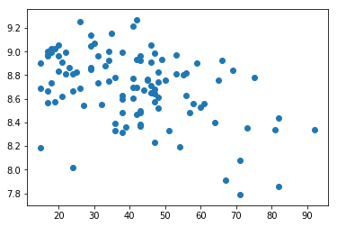

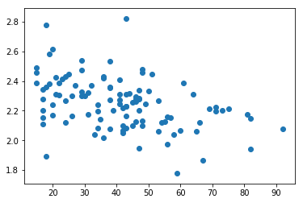

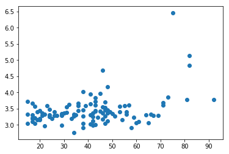

```python
for i in range(correlations):
    f = plt.figure()
    columnI = top_correlations[i][1]
    print("probeset ID:", probeset_IDs[columnI], "r**2:", top_correlations[i][0], "Bonf Corr p:", pearsonr(modal_allele, probeset_data[[columnI], :][0])[1] * probeset_data.shape[0])
    plt.scatter(modal_allele, probeset_data[[columnI], :])
```

# 8. Combining defined utility functions into a single `simulation_step` function

```python
def simulation_step(training_size=97, no_probes=500, n_components=10):
    training_i, testing_i = choose_training_indicies(probeset_data, training_size)
    training_fold, testing_fold = split_data(probeset_data, training_i, testing_i)
    modal_allele_training = [modal_allele[i] for i in training_i]
    modal_allele_testing = [modal_allele[i] for i in testing_i]

    top_500 = order_indicies(modal_allele_training, training_fold)[:no_probes]
    training_set = choose_top_genes(top_500, training_fold)
    testing_set = choose_top_genes(top_500, testing_fold)

    plsr = PLSRegression(n_components=n_components)

    plsr.fit(training_set.transpose(), cv(modal_allele_training))

    results = plsr.predict(testing_set.transpose())
    results = [i[0] for i in results]

    return modal_allele_testing, results
```

```python
a, b = simulation_step(training_size=70, no_probes=500, n_components=10)
```

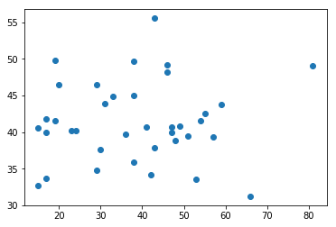

```python
plt.scatter(a, b)
```

# 9. Running the simulation 200 times and produce the scatter plot, r and r-squared

```python
real_alleles = []
simulated_alleles = []
for i in range(200):
    real_allele, simulated_allele = simulation_step(training_size=97, no_probes=500, n_components=10)
    real_alleles += real_allele
    simulated_alleles += simulated_allele
```

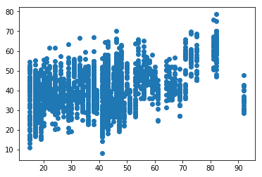

```python
plt.scatter(real_alleles, simulated_alleles)
r, p_value = pearsonr(real_alleles, simulated_alleles)
```

```python
from scipy.stats import pearsonr
r, p_value = pearsonr(real_alleles, simulated_alleles)
```

```python
r
```

```
0.39304421821454544
```

```python
r**2
```

```
0.1544837574718832
```

# 10. Runing a simulation to compute the probability that a random predictor would achieve the same $r^2$ or better (estimating the p-value)

```python
import random
import bisect
import math
r2s = []
sim = 10000
for i in range(sim):
    modal_allele_random = modal_allele[:]
    random.shuffle(modal_allele_random)
    inter_r, p_value = pearsonr(modal_allele, modal_allele_random)
    r2s.append(inter_r**2)
r2s.sort()
print(1 - bisect.bisect_right(r2s, r**2)/float(sim))
```

```
0.0
```

# 11. Printing the lowest $r^2$ which achieves a p-value of 0.05

```python
print(r2s[math.floor(0.95 * sim)])
```

```
0.0364519592727
```